# 20-Year Trend Analysis of Top 10 US Companies by Market Cap

#### Data Analaizing

##### Trend analysis

To understand the overall trend of the “adjusted_close” column

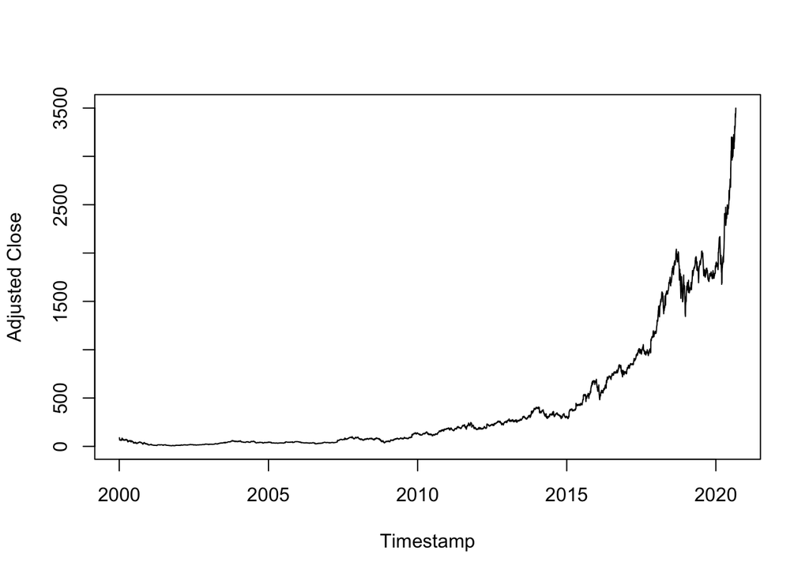

```r
# convert the "timestamp" column to a Date object in R
data$timestamp <- as.Date(data$timestamp, format = "%Y-%m-%d")

# then plot the timestamp and adjusted close
plot(data$timestamp, data$adjusted_close, type = "l", xlab = "Timestamp", ylab = "Adjusted Close")
```

```r
summary(data$adjusted_close)
```

```
##    Min. 1st Qu.  Median    Mean 3rd Qu.    Max.
##    5.97   41.38  129.66  428.36  440.29 3499.12
```

To analyze the trend in the “volume” column

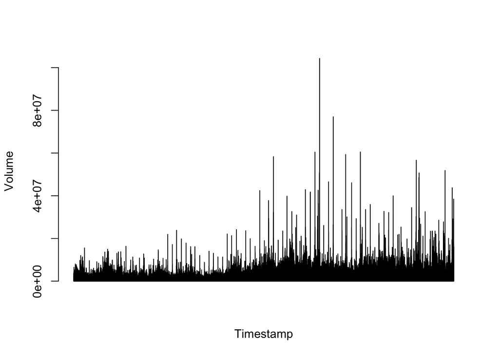

```r
barplot(data$volume, xlab = "Timestamp", ylab = "Volume")
```

```r
summary(data$volume)
```

```
##      Min.   1st Qu.    Median      Mean   3rd Qu.      Max.
##    881337   3624117   5373950   6491234   7758150 104329200
```

###### Comparison of performance

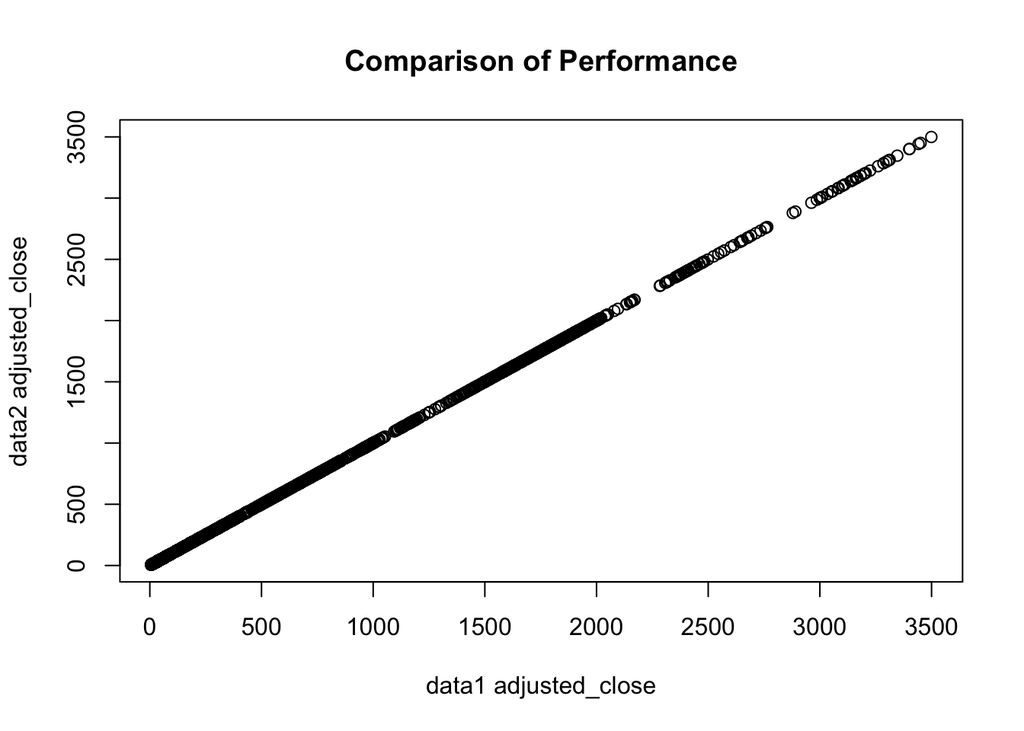

```r
plot(data$adjusted_close, data$adjusted_close, xlab = "data1 adjusted_close", ylab = "data2 adjusted_close", main = "Comparison of Performance")
```

```r
summary(data$adjusted_close)
```

```
##    Min. 1st Qu.  Median    Mean 3rd Qu.    Max.
##    5.97   41.38  129.66  428.36  440.29 3499.12
```

###### Prediction of future trends

To predict the future trend of “adjusted_close”, using time series analysis techniques.

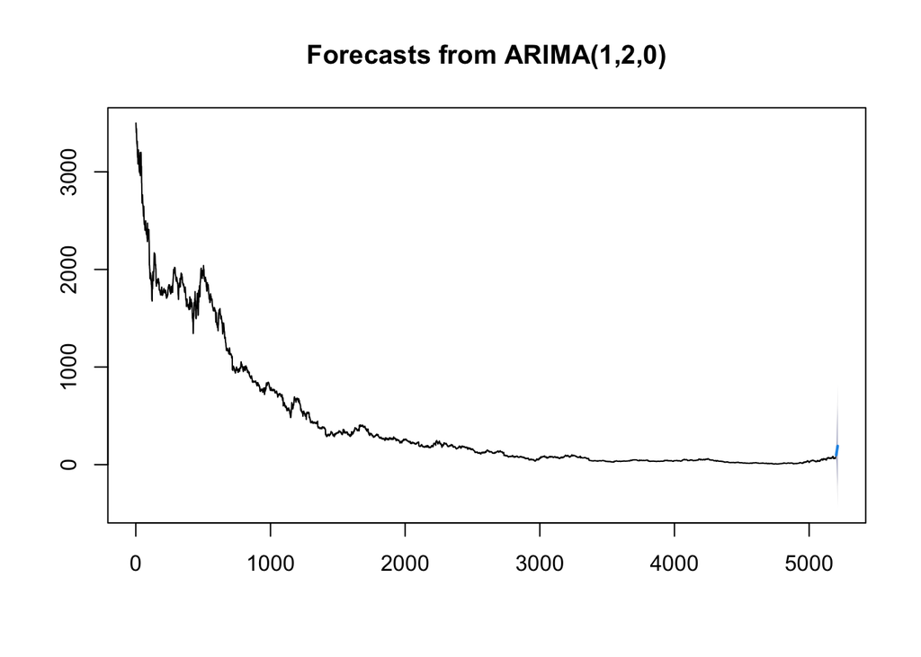

```r
library(forecast)
fit <- auto.arima(data$adjusted_close)
future_trend <- forecast(fit, h = 12)
plot(future_trend)
```

```r
summary(data$adjusted_close)
```

```
##    Min. 1st Qu.  Median    Mean 3rd Qu.    Max.
##    5.97   41.38  129.66  428.36  440.29 3499.12
```

###### Data visualization

creating a visualizations that represent the insights gained from the analysis

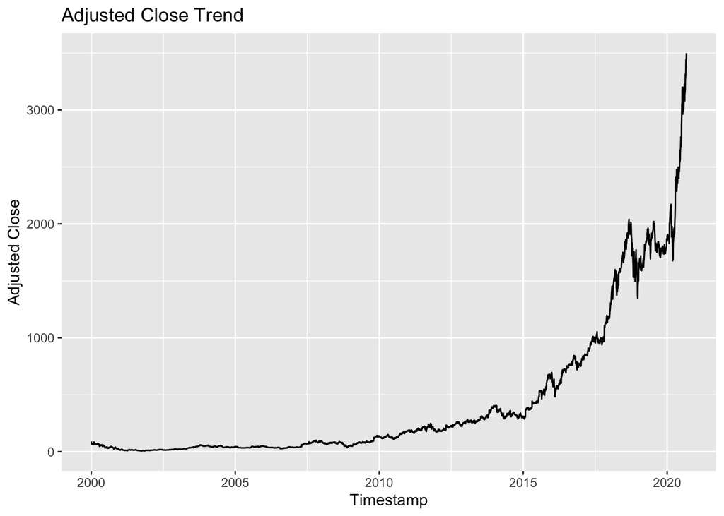

```r
library(ggplot2)
ggplot(data, aes(x = timestamp, y = adjusted_close)) +
  geom_line() +
  labs(x = "Timestamp", y = "Adjusted Close") +
  ggtitle("Adjusted Close Trend")
```

# conclistion

The conclusion based on the provided information is that the adjusted closing prices of the stocks in the data set tend to vary by around 634.5627 dollars from the mean value, with a standard deviation of 634.5627. The number of shares traded for the stocks tend to vary by around 5097986 shares from the mean value, with a standard deviation of 5097986. The trend in the adjusted closing prices of the stocks shows an upward trend over time. A time series analysis technique was used to predict the future trend of adjusted_close and the results were visualized using a line plot